# Generating dtopo files for CSZ fakequakes

This notebooks demonstrates how the GeoClaw `dtopotools` module can be used to generate the dtopo file for a kinematic rupture specified on a set of triangular subfaults (available starting in Clawpack Version 5.5.0).

This uses one of the 1300 "fakequake" realizations from the paper

- *Kinematic rupture scenarios and synthetic displacement data: An example application to the Cascadia subduction zone* by Diego Melgar, R. J. LeVeque, Douglas S. Dreger, Richard M. Allen, J. Geophys. Res. -- Solid Earth 121 (2016), p. 6658. [doi:10.1002/2016JB013314](http://dx.doi.org/10.1002/2016JB013314).

This requires `cascadia30.mshout` containing the geometry of the triangulated fault surface, from https://github.com/dmelgarm/MudPy/blob/master/examples/fakequakes/3D/cascadia30.mshout

It also requires a rupture scenario in the form of a `.rupt` file from the collection of fakequakes archived at https://zenodo.org/record/59943#.WgHuahNSxE4.

This sample uses one rupture scenario extracted from `data/cascadia.001297`.

### Version

Animation revised 2020-07-26 to run with v5.7.0

```python
%matplotlib inline
```

```python
from clawpack.geoclaw import dtopotools
import matplotlib.pyplot as plt
from mpl_toolkits.mplot3d import Axes3D
import numpy as np
from copy import copy
from clawpack.visclaw import animation_tools
import os
from IPython.display import HTML
```

### Set up CSZ geometry

```python
fault_geometry_file = './cascadia30.mshout'
print('Reading fault geometry from %s' % fault_geometry_file)
print('\nHeader:\n')
print(open(fault_geometry_file).readline())
```

```
Reading fault geometry from ./cascadia30.mshout

Header:

#   fault No. , centroid(lon,lat,z[km]) , node1(lon,lat,z[km]) , node2(lon,lat,z[km]) , node3(lon,lat,z[km]) , mean vertex length(km) , area(km^2) , strike(deg) , dip(deg)
```

```python
# read in .mshout (CSZ geoemetry)

cascadia = np.loadtxt(fault_geometry_file,skiprows=1)
cascadia[:,[3,6,9,12]] = 1e3*abs(cascadia[:,[3,6,9,12]])

print('Loaded geometry for %i triangular subfaults' % cascadia.shape[0])
```

```
Loaded geometry for 963 triangular subfaults
```

For example, the first triangular fault in the given geometry of CSZ has the nodes

```python
print(cascadia[0,4:7])
print(cascadia[0,7:10])
print(cascadia[0,10:13])
```

```
[-125.36073    46.302805 8795.382   ]
[ -125.311684    46.526803 10094.313   ]
[ -125.038743    46.426986 13526.373   ]
```

### Plot the subfaults:

Set up a fault model with these subfaults, without yet specifying a particular earthquake scenario.

```python
fault0 = dtopotools.Fault()
fault0.subfaults = []

nsubfaults = cascadia.shape[0]

for j in range(nsubfaults):
    subfault0 = dtopotools.SubFault()
    node1 = cascadia[j,4:7].tolist()
    node2 = cascadia[j,7:10].tolist()
    node3 = cascadia[j,10:13].tolist()
    node_list = [node1,node2,node3]
    subfault0.set_corners(node_list,projection_zone='10T')
    fault0.subfaults.append(subfault0)
```

Now we can plot the triangular subplots:

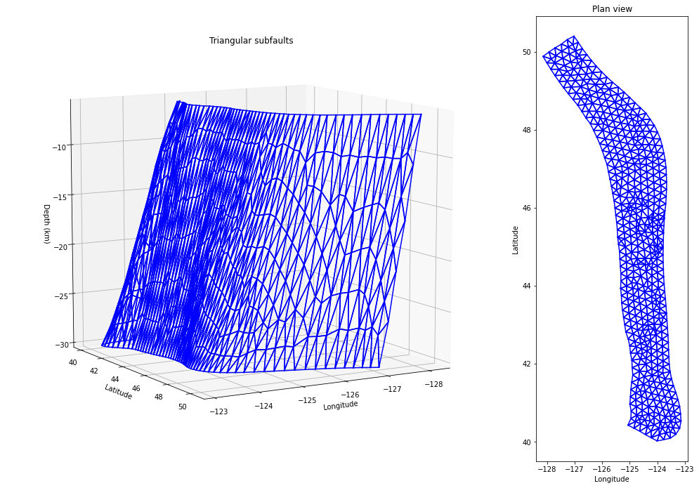

```python
fig = plt.figure(figsize=(15,10))
#ax = fig.add_subplot(121, projection='3d')
ax = fig.add_axes([.05,.05,.65,.9], projection='3d')
for s in fault0.subfaults:
    c = s.corners
    c.append(c[0])
    c = np.array(c)
    ax.plot(c[:,0],c[:,1],-c[:,2]/1000.,color='b')
ax.view_init(10,60)
ax.set_xlabel('Longitude')
ax.set_ylabel('Latitude')
ax.set_zlabel('Depth (km)')
ax.set_title('Triangular subfaults')

#ax = fig.add_subplot(122)
ax = fig.add_axes([.75,.05,.2,.9])
for s in fault0.subfaults:
    c = s.corners
    c.append(c[0])
    c = np.array(c)
    ax.plot(c[:,0],c[:,1], 'b')
ax.set_aspect(1./np.cos(45*np.pi/180.))
ax.set_xlabel('Longitude')
ax.set_ylabel('Latitude')
ax.set_title('Plan view')
```

### Rupture scenario

We now read in rupture scenario, using data from [https://zenodo.org/record/59943#.WgHuahNSxE4].

```python
rupt_fname = '_cascadia.001297.rupt'
print("Reading earthquake data from %s" % rupt_fname)
rupture_parameters = np.loadtxt(rupt_fname,skiprows=1)
```

```
Reading earthquake data from _cascadia.001297.rupt
```

This data is used to set the slip and rake on each of the subfaults loaded above. Since this is a dynamic rupture, we also set the `rupture_time` and `rise_time` of each subfault.

```python
fault0 = dtopotools.Fault()
fault0.subfaults = []
fault0.rupture_type = 'kinematic'
rake = 90. # assume same rake for all subfaults

J = int(np.floor(cascadia.shape[0]))

for j in range(J):
    subfault0 = dtopotools.SubFault()
    node1 = cascadia[j,4:7].tolist()
    node2 = cascadia[j,7:10].tolist()
    node3 = cascadia[j,10:13].tolist()
    node_list = [node1,node2,node3]

    ss_slip = rupture_parameters[j,8]
    ds_slip = rupture_parameters[j,9]

    rake = np.rad2deg(np.arctan2(ds_slip, ss_slip))

    subfault0.set_corners(node_list,projection_zone='10T')
    subfault0.rupture_time = rupture_parameters[j,12]
    subfault0.rise_time = rupture_parameters[j,7]
    subfault0.rake = rake

    slip = np.sqrt(ds_slip ** 2 + ss_slip ** 2)
    subfault0.slip = slip
    fault0.subfaults.append(subfault0)
```

### Compute seafloor deformations with GeoClaw

We now run the `create_dtopography` routine to generate dynamic seafloor deformations at a given set of times. This applies the Okada model to each of the subfaults and evaluates the surface displacement on the grid given by `x,y`, at each time. These are summed up over all subfaults to compute the total deformation.

```python
x,y = fault0.create_dtopo_xy(dx = 4/60.)
print('Will create dtopo on arrays of shape %i by %i' % (len(x),len(y)))
tfinal = max([subfault1.rupture_time + subfault1.rise_time for subfault1 in fault0.subfaults])
times0 = np.linspace(0.,tfinal,100)
dtopo0 = fault0.create_dtopography(x,y,times=times0,verbose=True);
```

```
Will create dtopo on arrays of shape 106 by 181
Making Okada dz for each of 963 subfaults
0..1..2..3..4..5..6..7..8..9..10..11..12..13..14..15..16..17..18..19..20..21..22..23..24..25..26..27..28..29..30..31..32..33..34..35..36..37..38..39..40..41..42..43..44..45..46..47..48..49..50..51..52..53..54..55..56..57..58..59..60..61..62..63..64..65..66..67..68..69..70..71..72..73..74..75..76..77…
Done
```

```python
x.shape,y.shape, dtopo0.dZ.shape
```

```
((106,), (181,), (100, 181, 106))
```

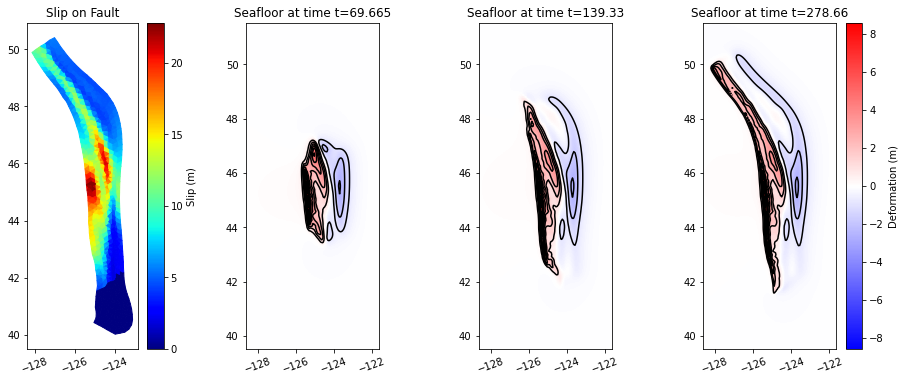

```python
fig,(ax0,ax1,ax2, ax3) = plt.subplots(ncols=4,nrows=1,figsize=(16,6))
fault0.plot_subfaults(axes=ax0,slip_color=True,plot_box=False);
ax0.set_title('Slip on Fault');

X = dtopo0.X; Y = dtopo0.Y; dZ_at_t = dtopo0.dZ_at_t
dz_max = dtopo0.dZ.max()

t0 = 0.25*tfinal    # time to plot deformation
dtopotools.plot_dZ_colors(X,Y,dZ_at_t(t0),axes=ax1,
                          cmax_dZ = dz_max, add_colorbar=False);
ax1.set_title('Seafloor at time t=' + str(t0));

t0 = 0.5*tfinal    # time to plot deformation
dtopotools.plot_dZ_colors(X,Y,dZ_at_t(t0),axes=ax2,
                          cmax_dZ = dz_max, add_colorbar=False);

ax2.set_title('Seafloor at time t=' + str(t0));

t0 = tfinal    # time to plot deformation
dtopotools.plot_dZ_colors(X,Y,dZ_at_t(t0),axes=ax3,
                          cmax_dZ = dz_max, add_colorbar=True);
ax3.set_title('Seafloor at time t=' + str(t0));

#fig.savefig('CSZ_triangular.png');
```

### Plot the rupture time and rise time of each subfault

This shows where the rupture originates and how it propagates outward. Each vertical bar shows the rupture time and duration of one subfault.

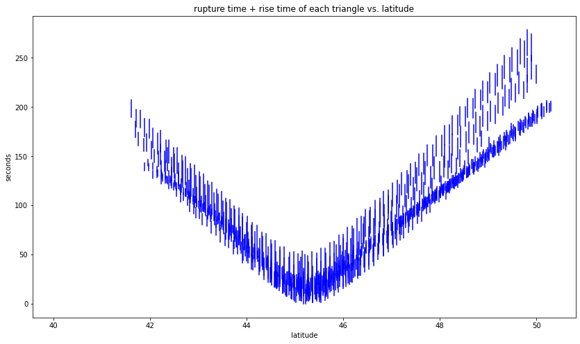

```python
plt.figure(figsize=(14,8))
plt.axes()
latitudes = [s.latitude for s in fault0.subfaults]
rise_times = [s.rise_time for s in fault0.subfaults]
rupture_times = [s.rupture_time for s in fault0.subfaults]
for j,lat in enumerate(latitudes):
    plt.plot([lat,lat],[rupture_times[j],rupture_times[j]+rise_times[j]],'b')
plt.xlabel('latitude')
plt.ylabel('seconds')
plt.title('rupture time + rise time of each triangle vs. latitude')
```

### Plot the deformation as a function of time at a few locations

Same longitude, increasing latitude...

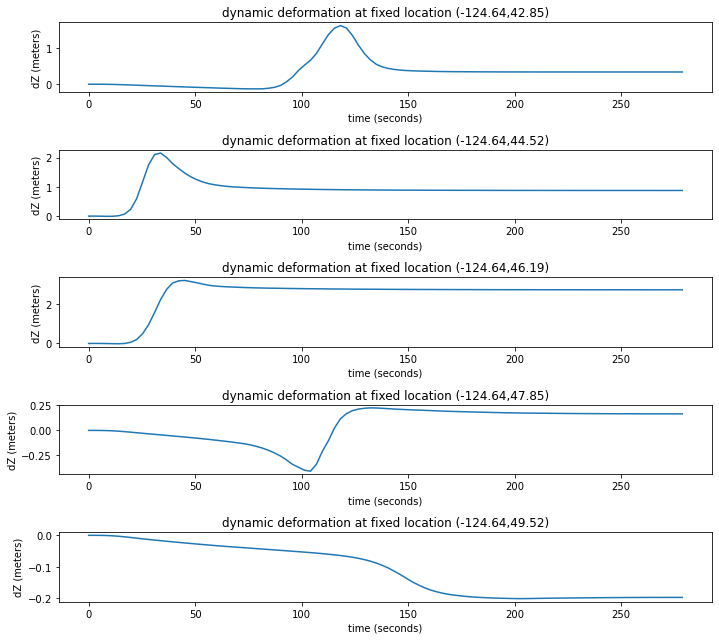

```python
plt.figure(figsize=(10,9))
for kk in range(5):
    plt.subplot(5,1,kk+1)
    j = 60
    k = 50 + 25*kk
    plt.title('dynamic deformation at fixed location (' + '{:4.2f}'.format(x[j]) \
                                                 + ',' + '{:4.2f}'.format(y[k]) + ')' )
    plt.plot(dtopo0.times,dtopo0.dZ[:,k,j]);
    plt.ylabel('dZ (meters)');
    plt.xlabel('time (seconds)');
plt.tight_layout()
```

### Create a dtopo file for GeoClaw

```python
ruptno = rupt_fname.split('.')[1]
fname = 'cascadia' + ruptno + '.dtt3'
dtopo0.write(fname, dtopo_type=3)
```

```python
print('Created %s, with dynamic rupture of a Mw %.2f event' % (fname, fault0.Mw()))
```

```
Created cascadia001297.dtt3, with dynamic rupture of a Mw 9.09 event
```

### Animate the rupture:

This fails in v5.5.0 due to a typo that was later fixed in `clawpack/geoclaw` commit 9422715, and should be fixed in v5.6.0.

```python
dz_max = abs(dtopo0.dZ).max()

# Incorporate this function in dtopotools to replace animate_dz_colors?
def plot_subfaults_dZ(t, fig):
    fig.clf()
    ax1 = fig.add_subplot(121)
    ax2 = fig.add_subplot(122)
    fault0.plot_subfaults(axes=ax1, slip_color=True, plot_box=False,
                          slip_time=t)
    dtopo0.plot_dZ_colors(axes=ax2, t=t, cmax_dZ=dz_max)
    return fig

figs = []
times = dtopo0.times[::5]   # only use every 5th time for animation
if dtopo0.times[-1] not in times:
    times = np.hstack((times, dtopo0.times[-1]))  # include final dz

print('Animation will include %i times' % len(times))
for k,t in enumerate(times):
    fig = plt.figure(figsize=(12,5))
    plot_subfaults_dZ(t,fig)
    figs.append(fig)
    plt.close(fig)
```

```
Animation will include 21 times
```

```python
anim = animation_tools.animate_figs(figs, figsize=(12,6))
```

```python
HTML(anim.to_jshtml())
```

[figure not shown]